# LAB03CDP

José Glauber

31 de outubro de 2018

## Importanto os dados e bibliotecas necessárias para as respostas das questões!

```r
knitr::opts_chunk$set(echo = TRUE, warning=FALSE, message=FALSE)
library(readr)
library(caret)
library(dplyr)
```

```r
library(ggplot2)
```

# Carregando informações e retirando informações que não são interessantes para o nosso modelo (discutido anteriormente)

```r
train_set <- read.csv("train.csv")
train <- train_set %>% select(-cargo, -nome, -sequencial_candidato, -ocupacao)
```

## Perguntas

1. Usando todas as variáveis disponíveis, tune (usando validação cruzada): (i) um modelo de regressão Ridge, (ii) um modelo de regressão Lasso e (iii) um modelo KNN. Para os modelos de regressão linear, o parâmetro a ser tunado é o lambda (penalização dos coeficientes) e o KNN o número de vizinhos.

# Validação cruzada

```r
train_control <- trainControl(method = "cv", number = 5)

preProcValues <- c("center", "scale", "nzv")
```

1. um modelo de regressão Ridge

```r
model.ridge <- train(votos ~ .,
               data = train,
               trControl = train_control,
               method = "ridge",
               preProcess = preProcValues,
               tuneLength = 20)
model.ridge
```

```
## Ridge Regression
##
## 7476 samples
##   19 predictor
##
## Pre-processing: centered (32), scaled (32), remove (49)
## Resampling: Cross-Validated (5 fold)
## Summary of sample sizes: 5980, 5981, 5982, 5981, 5980
## Resampling results across tuning parameters:
##
##   lambda        RMSE       Rsquared   MAE
##   0.0000000000  190032.51  0.3024003  20349.76
##   0.0001000000   37920.89  0.3819778  16233.48
##   0.0001467799   37917.52  0.3820602  16233.25
##   0.0002154435   37912.85  0.3821749  16232.93
##   0.0003162278   37906.55  0.3823308  16232.51
##   0.0004641589   37898.36  0.3825357  16232.00
##   0.0006812921   37888.27  0.3827922  16231.42
##   0.0010000000   37876.79  0.3830922  16230.99
##   0.0014677993   37865.19  0.3834099  16230.78
##   0.0021544347   37855.70  0.3836977  16231.18
##   0.0031622777   37851.35  0.3838890  16232.01
##   0.0046415888   37855.47  0.3839112  16234.34
##   0.0068129207   37870.96  0.3837056  16237.18
##   0.0100000000   37899.66  0.3832478  16240.85
##   0.0146779927   37942.23  0.3825577  16242.41
##   0.0215443469   37998.79  0.3816922  16239.69
##   0.0316227766   38070.37  0.3807231  16230.97
##   0.0464158883   38160.96  0.3797075  16208.17
##   0.0681292069   38280.22  0.3786620  16167.88
##   0.1000000000   38447.35  0.3775499  16112.08
##
## RMSE was used to select the optimal model using the smallest value.
## The final value used for the model was lambda = 0.003162278.
```

2. O modelo de regressão Lasso

```r
model.lasso <- train(votos ~ .,
                     data = train,
                     trControl = train_control,
                     method = "lasso",
                     preProcess = preProcValues,
                     tuneLength = 20)
model.lasso
```

```
## The lasso
##
## 7476 samples
##   19 predictor
##
## Pre-processing: centered (32), scaled (32), remove (49)
## Resampling: Cross-Validated (5 fold)
## Summary of sample sizes: 5980, 5981, 5981, 5980, 5982
## Resampling results across tuning parameters:
##
##   fraction   RMSE       Rsquared   MAE
##   0.1000000   46821.29  0.2940204  16647.40
##   0.1421053   51165.42  0.2833578  16769.49
##   0.1842105   55662.30  0.2781621  16891.58
##   0.2263158   60232.91  0.2753192  17013.67
##   0.2684211   64844.29  0.2736134  17135.76
##   0.3105263   69480.46  0.2725148  17257.85
##   0.3526316   74132.77  0.2717676  17379.94
##   0.3947368   78796.19  0.2712367  17502.03
##   0.4368421   83467.56  0.2708461  17624.12
##   0.4789474   88144.81  0.2705503  17746.21
##   0.5210526   92826.54  0.2703208  17868.30
##   0.5631579   97511.74  0.2701391  17990.39
##   0.6052632  102199.72  0.2699926  18112.49
##   0.6473684  106889.92  0.2698727  18234.58
##   0.6894737  111581.94  0.2697733  18356.67
##   0.7315789  116275.48  0.2696898  18478.76
##   0.7736842  120970.28  0.2696189  18601.06
##   0.8157895  125666.15  0.2695582  18723.70
##   0.8578947  130362.93  0.2695058  18846.33
##   0.9000000  135060.50  0.2694601  18968.97
##
## RMSE was used to select the optimal model using the smallest value.
## The final value used for the model was fraction = 0.1.
```

3. O modelo KNN

```r
model.knn <- train(votos ~ .,
                   data = train,
                   method = "knn",
                   trControl = train_control,
                   preProcess = preProcValues,
                   tuneLength = 20)
model.knn
```

```
## k-Nearest Neighbors
##
## 7476 samples
##   19 predictor
##
## Pre-processing: centered (32), scaled (32), remove (49)
## Resampling: Cross-Validated (5 fold)
## Summary of sample sizes: 5981, 5981, 5981, 5981, 5980
## Resampling results across tuning parameters:
##
##   k   RMSE      Rsquared   MAE
##    5  35513.84  0.4553599  13950.25
##    7  35215.90  0.4642376  13872.00
##    9  35164.83  0.4675346  13907.63
##   11  35113.45  0.4717439  13893.90
##   13  35103.21  0.4733505  13981.99
##   15  35198.43  0.4718343  14073.87
##   17  35266.71  0.4712456  14096.44
##   19  35344.16  0.4687142  14179.65
##   21  35513.24  0.4639137  14286.56
##   23  35561.96  0.4635461  14340.05
##   25  35576.52  0.4642285  14389.44
##   27  35657.78  0.4625224  14460.82
##   29  35721.41  0.4611206  14491.56
##   31  35812.53  0.4584940  14579.84
##   33  35886.22  0.4564297  14625.83
##   35  35906.26  0.4563396  14634.42
##   37  35970.58  0.4544995  14673.57
##   39  36036.48  0.4534055  14703.26
##   41  36119.73  0.4508776  14738.46
##   43  36191.69  0.4490126  14796.65
##
## RMSE was used to select the optimal model using the smallest value.
## The final value used for the model was k = 13.
```

2. Compare os três modelos em termos do erro RMSE de validação cruzada.

Podemos verificar que dentro os modelos, o menor RMSE é o do modelo KNN, em seguida temos o do Ridge e por último, o Lasso.

3. Quais as variáveis mais importantes segundo o modelo de regressão Ridge e Lasso? Variáveis foram descartadas pelo Lasso? Quais?

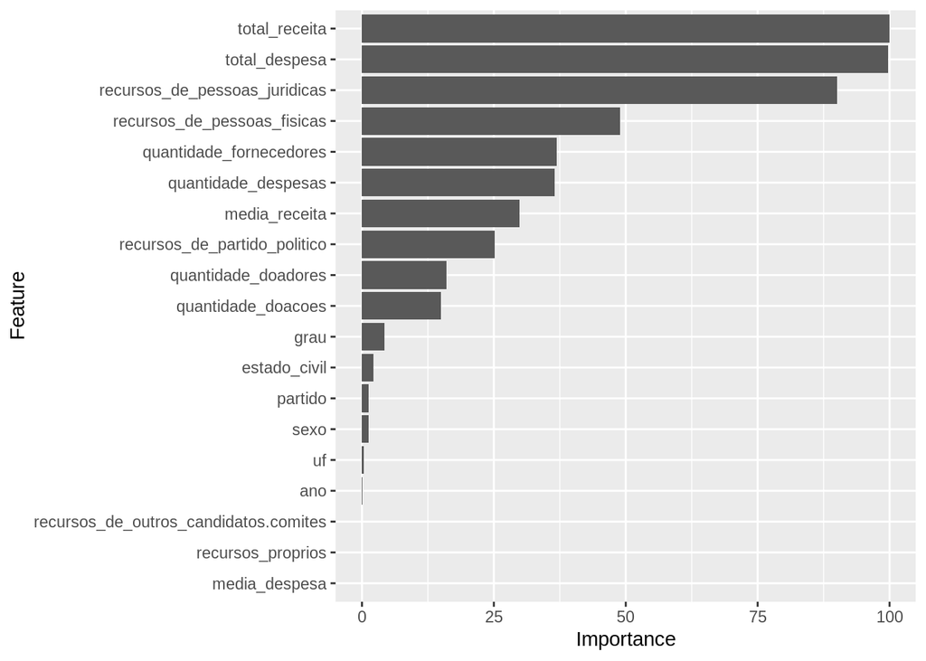

```r
ggplot(varImp(model.ridge))
```

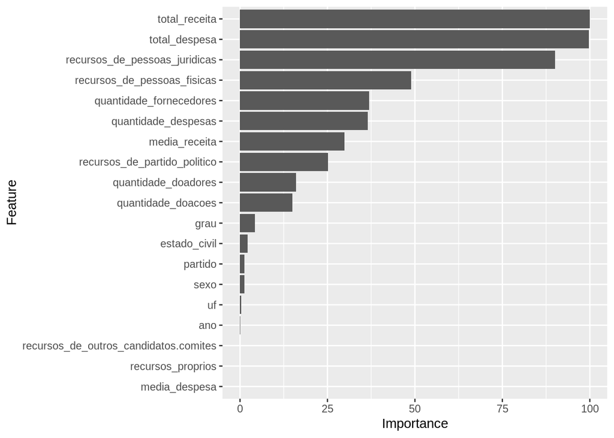

```r
ggplot(varImp(model.lasso))
```

4. Re-treine o melhor modelo (usando os melhores valores de parâmetros encontrados em todos os dados, sem usar validação cruzada).

```r
best <- expand.grid(k = model.knn$bestTune)

best.model <- train(votos ~ .,
                    data = train,
                    method = "knn",
                    tuneGrid = best)
best.model
```

```
## k-Nearest Neighbors
##
## 7476 samples
##   19 predictor
##
## No pre-processing
## Resampling: Bootstrapped (25 reps)
## Summary of sample sizes: 7476, 7476, 7476, 7476, 7476, 7476, ...
## Resampling results:
##
##   RMSE      Rsquared   MAE
##   33934.42  0.4931242  12651.94
##
## Tuning parameter 'k' was held constant at a value of 13
```

5. Use esse último modelo treinado para prever os dados de teste disponíveis no challenge que criamos na plataforma Kaggle.

```r
test <- read.csv("test.csv")
submission <- test %>%
  select(sequencial_candidato)
test <- test %>%
  select(-sequencial_candidato,
         -nome,
         -cargo,
         -ocupacao)
predictions <- predict(best.model, test)
submission$votos <- predictions
submission <- submission %>%
  select(ID = sequencial_candidato,
         votos = votos)
write.csv(x = submission,
          file = "sample_submission.csv",
          row.names = FALSE)
```